# STAT 410 Project

Allie Shelton

2024-05-04

Hierarchical clustering:

We will take a look at the most common type of hierarchical clustering called agglomerative clustering.

Agglomerative Clustering is used to group objects into clusters based on their similarity.

The algorithm starts by treating each object as a singleton cluster. Next, pairs of clusters are successively merged until all clusters have been merged into one big cluster containing all objects. The result is a tree-based representation of the objects, named dendrogram.

Agglomerative clustering works in a “bottom-up” manner. That is, each object is initially considered as a single-element cluster (leaf). At each step of the algorithm,the two clusters that are the most similar are combined into a new bigger cluster (nodes). This procedure is iterated until all points are member of just one single big cluster (root)

(Kassambara, 2017)

We will look at the USArrests data set to explore agglomerative clustering.

USArrests has 50 rows representing each US state and 4 columns representing the murder, assault, urban pop, and rape rates per 100,000

```
##            Murder Assault UrbanPop Rape
## Alabama      13.2     236       58 21.2
## Alaska       10.0     263       48 44.5
## Arizona       8.1     294       80 31.0
## Arkansas      8.8     190       50 19.5
## California    9.0     276       91 40.6
## Colorado      7.9     204       78 38.7
```

We need to scale the data. We scale the data because this way all the data points will be on the same “scale” for example two different data points could be measured in kg and lbs, we want them on the same scale.

```r
arrests <- scale(USArrests)
```

To see which clustered should be combined/divided we need a method for measuring the similarity between the objects.

We will use the dist function which computes the Euclidean distance (distance between two objects). The smaller the distance the more similar they are.

Euclidean distance formula:

$$\text{Euclidean Distance} = \sqrt{\sum_{i=1}^{n} (x_i - y_i)^2}$$

```r
## use the dist function
distance <- dist(arrests, method = "euclidean")

## create a matrix of the dist function
distance_matrix <- as.matrix(distance)

##head(distance_matrix)
```

The linkage function takes the distance information, returned by the function dist(),and groups pairs of objects into clusters based on their similarity. Then, these newly formed clusters are linked to each other to create bigger clusters. This process is iterated until all the objects in the original data set are linked together in a hierarchical tree. (Kassambara, 2017)

Ward’s minimum variance method: This method minimizes the total within-cluster variance. At each step the pair of clusters with minimum between-cluster distance are merged.

```r
## minimizing total within-cluster-variance

H_tree <- hclust(d = distance, method = "ward.D2")
```

The function fviz_dend() from the factoexrta package will create a graphical representation of our hierarchical tree called a dendrogram.

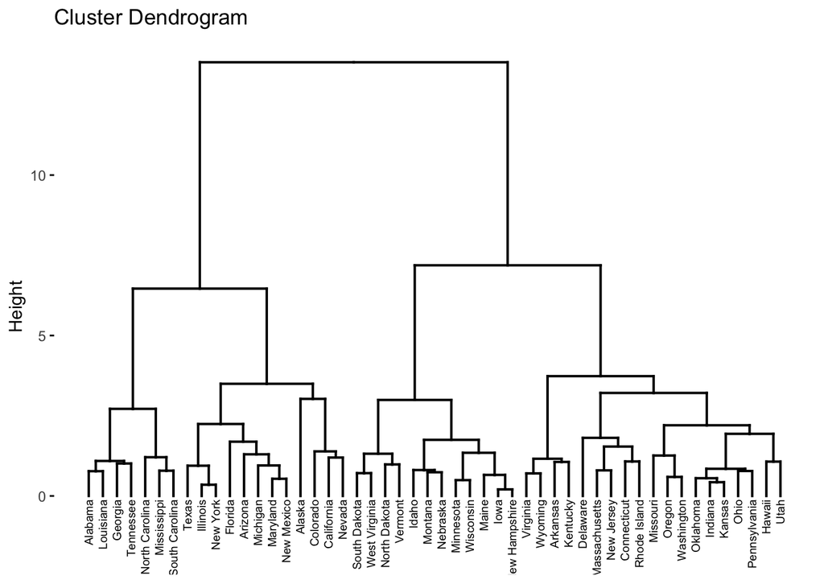

```r
## create a dendrogram

fviz_dend(H_tree, cex = 0.5)
```

-In the above dendrogram, each object that is similar is connected in a branch, as we go up the tree similar objects are combined into the branch.

-As the height of the tree increases, the less similar the objects are.

-The height is known as the cophenetic distance between the two objects. The cophenetic distance reflects how similar or dissimilar two clusters are before they are merged. The higher the height, the greater the cophenetic distance, and consequently, the lower the similarity between the merged clusters. (Kassambara, 2017)

The formula for calculating the cophenetic distance between two observations $i$ and $j$ in hierarchical clustering is:

$$\text{Cophenetic Distance}_{ij} = \text{Height of the Dendrogram at
Which Clusters \(i\) and \(j\) Merge}$$

HOW DO WE KNOW THE CLUSTER TREE IS ACCURATE?

One way to measure how well the cluster tree generated by the hclust() function reflects your data is to compute the correlation between the cophenetic distances and the original distance data generated by the dist() function.

If the clustering is valid, the linking of objects in the cluster tree should have a strong correlation with the distances between objects in the original distance matrix. We are typically looking for a correlation above 0.75.

```r
## compute cophentic distance
cophenetic_dist <- cophenetic(H_tree)

## compute correlation between cophentic and original distance
cor(distance,cophenetic_dist)
```

```
## [1] 0.6975266
```

Because the correlation between the cophentic and original distance is only 0.697 (we are looking for 0.75 and above) we will execute the hclust() function again using the average linkage method. The average linkage method is a method used in hierarchical clustering to determine the distance between two clusters.

Average linkage method: The distance between two clusters is defined as the average distance between the elements in cluster 1 and the elements in cluster 2.

```r
H_tree2 <- hclust(distance, method = "average")


cor(distance, cophenetic(H_tree2))
```

```
## [1] 0.7180382
```

The correlation coefficient of 0.718 shows us that using the average linkage method creates a tree that represents our original data a bit better. Even though the correlation is slightly better, we will continue the rest of this example with the Ward.D2 method. The reason we will continue with this method is because Ward’s method is generally preferred over the average linkage method.

CUTTING THE DENDROGRAM INTO DIFFERENT GROUPS:

Hierarchical clustering does not tell us how many clusters there are or where to cut the dendrogram off to form our clusters. We can look at the dendrogram to see where the best cut off seems to be. If we look at the dendrogram above, we can see that 4 looks like the optimal number.

The function cutree() can be used to cut a tree into several groups, either by specifying the number of groups or the cut height.

```
##    Alabama     Alaska    Arizona   Arkansas California   Colorado
##          1          2          2          3          2          2
```

```
## grp
##  1  2  3  4
##  7 12 19 12
```

```
## [1] "Alabama"        "Georgia"        "Louisiana"      "Mississippi"
## [5] "North Carolina" "South Carolina" "Tennessee"
```

```
##  [1] "Alaska"     "Arizona"    "California" "Colorado"   "Florida"
##  [6] "Illinois"   "Maryland"   "Michigan"   "Nevada"     "New Mexico"
## [11] "New York"   "Texas"
```

```
##  [1] "Arkansas"      "Connecticut"   "Delaware"      "Hawaii"
##  [5] "Indiana"       "Kansas"        "Kentucky"      "Massachusetts"
##  [9] "Missouri"      "New Jersey"    "Ohio"          "Oklahoma"
## [13] "Oregon"        "Pennsylvania"  "Rhode Island"  "Utah"
## [17] "Virginia"      "Washington"    "Wyoming"
```

```
##  [1] "Idaho"         "Iowa"          "Maine"         "Minnesota"
##  [5] "Montana"       "Nebraska"      "New Hampshire" "North Dakota"
##  [9] "South Dakota"  "Vermont"       "West Virginia" "Wisconsin"
```

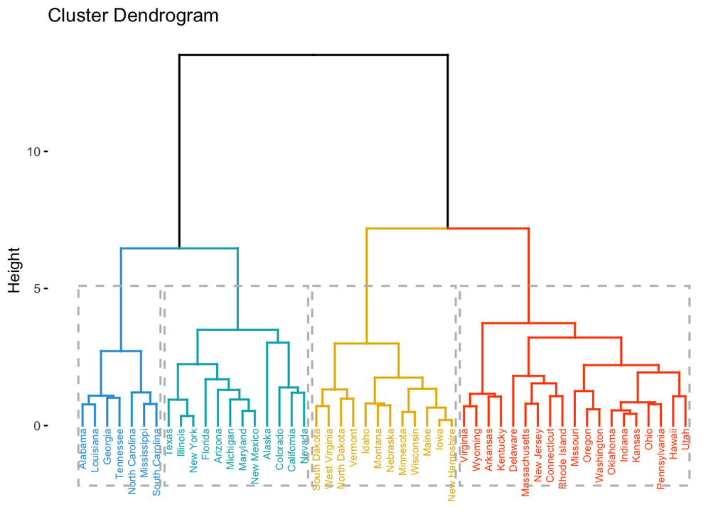

```r
# Cut in 4 groups and color by groups
fviz_dend(H_tree, k = 4, # Cut in four groups
cex = 0.5, # label size
k_colors = c("#2E9FDF", "#00AFBB", "#E7B800", "#FC4E07"),
color_labels_by_k = TRUE, # color labels by groups
rect = TRUE # Add rectangle around groups
)
```

Based on the dendrogram above, we can clearly see which objects are in the same cluster by the colors. There is also a rectangular box around the clusters for more clarity.

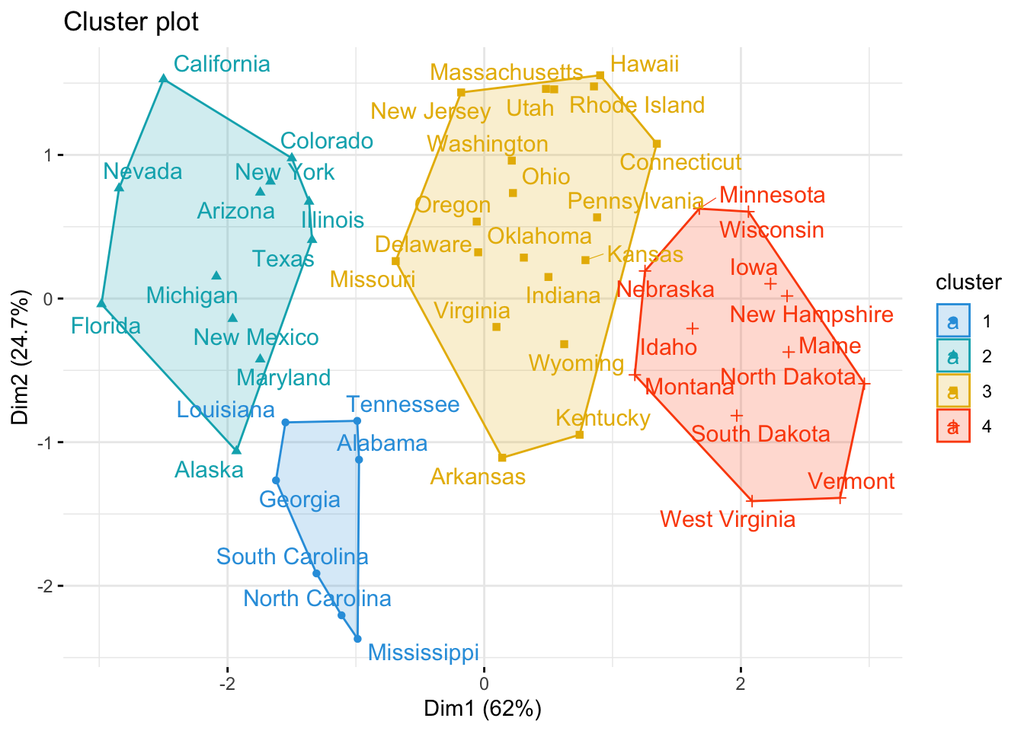

```r
## visualize as a scatter plot
fviz_cluster(list(data = arrests, cluster = grp),
palette = c("#2E9FDF", "#00AFBB", "#E7B800", "#FC4E07"),
ellipse.type = "convex", # Concentration ellipse
repel = TRUE, # Avoid label overplotting (slow)
show.clust.cent = FALSE, ggtheme = theme_minimal())
```

Let’s use these new techniques to explore LA crime data.:

Research Question : :

How can we group the 21 geographical areas of LA when considering the top 5 crimes based on victim demographics such as age and gender, and crime count? Based off of these groupings, how do the victim demographics and crime count compare?

This is a very important topic as it gives us insights on crime patterns in LA. Understanding these crimes patterns is critical as it allows for police and government officials to create targeted strategies and plans to address and prevent crimes. Knowing the crime patterns will help keep residents of the city safe. Using cluster analysis for this research will give us the ability to uncover hidden relationships and patterns within the data, allowing for a deeper understanding of crime dynamics across different regions in LA.

Data description:

The data set we will be exploring contains crime data in Los Angeles from 2020 to present day. This data set is quite large as it has 932K rows and 28 columns. For the purpose of this research we will cut down the data to only contain 4 variables, namely: Area, Crm.Cd.Desc, Vict.Age, and Vict.sex.

-Area represents one of the 21 LAPD police stations (referred to as geographical areas).

-Crm.Cd.Desc represents the type of crime provided

-Vict.Age refers to the victims age.

-Vict.sex refers to the victims sex.

```r
#setwd("/Users/allieshelton/Downloads/")
LAcrime <- read.csv("Crime_Data_from_2020_to_Present_20240417.csv")

head(LAcrime)
```

```
##       DR_NO              Date.Rptd               DATE.OCC TIME.OCC AREA
## 1 190326475 03/01/2020 12:00:00 AM 03/01/2020 12:00:00 AM     2130    7
## 2 200106753 02/09/2020 12:00:00 AM 02/08/2020 12:00:00 AM     1800    1
## 3 200320258 11/11/2020 12:00:00 AM 11/04/2020 12:00:00 AM     1700    3
## 4 200907217 05/10/2023 12:00:00 AM 03/10/2020 12:00:00 AM     2037    9
## 5 220614831 08/18/2022 12:00:00 AM 08/17/2020 12:00:00 AM     1200    6
## 6 231808869 04/04/2023 12:00:00 AM 12/01/2020 12:00:00 AM     2300   18
##   AREA.NAME Rpt.Dist.No Part.1.2 Crm.Cd
## 1  Wilshire         784        1    510
## 2   Central         182        1    330
## 3 Southwest         356        1    480
## 4  Van Nuys         964        1    343
## 5 Hollywood         666        2    354
## 6 Southeast        1826        2    354
##                                Crm.Cd.Desc             Mocodes Vict.Age
```

[output cut: 34 more lines]

```
## [1] 139
```

There are 139 unique crimes. Using all 139 crimes would be a bit messy for clustering. We will take the five most frequent occurring crimes to investigate.

We will now identify the top 5 most common crimes:

```
## # A tibble: 5 × 2
##   Crm.Cd.Desc              Crime_Count
##   <chr>                          <int>
## 1 VEHICLE - STOLEN              100225
## 2 BATTERY - SIMPLE ASSAULT       73759
## 3 THEFT OF IDENTITY              57539
## 4 BURGLARY FROM VEHICLE          57538
## 5 BURGLARY                       57015
```

The top five most occuring crimes include, vehicle-stolen, battery-simple assault, theft of identity, burglary from vehicle, and burglary.

Now we will remove all crimes, other than the ones of interest:

```
##       DR_NO              Date.Rptd               DATE.OCC TIME.OCC AREA
## 1 190326475 03/01/2020 12:00:00 AM 03/01/2020 12:00:00 AM     2130    7
## 2 200106753 02/09/2020 12:00:00 AM 02/08/2020 12:00:00 AM     1800    1
## 3 220614831 08/18/2022 12:00:00 AM 08/17/2020 12:00:00 AM     1200    6
## 4 231808869 04/04/2023 12:00:00 AM 12/01/2020 12:00:00 AM     2300   18
## 5 230110144 04/04/2023 12:00:00 AM 07/03/2020 12:00:00 AM      900    1
## 6 220314085 07/22/2022 12:00:00 AM 05/12/2020 12:00:00 AM     1110    3
##   AREA.NAME Rpt.Dist.No Part.1.2 Crm.Cd           Crm.Cd.Desc
## 1  Wilshire         784        1    510      VEHICLE - STOLEN
## 2   Central         182        1    330 BURGLARY FROM VEHICLE
## 3 Hollywood         666        2    354     THEFT OF IDENTITY
## 4 Southeast        1826        2    354     THEFT OF IDENTITY
## 5   Central         182        2    354     THEFT OF IDENTITY
## 6 Southwest         303        2    354     THEFT OF IDENTITY
##               Mocodes Vict.Age Vict.Sex Vict.Descent Premis.Cd
```

[output cut: 27 more lines]

We will now remove any variables that are not useful in answering our research question. We will also remove any rows that have an unknown victim age as well as a missing value for victim gender

```
## [1] "M" "F"
```

```
##   AREA           Crm.Cd.Desc Vict.Age Vict.Sex
## 1    1 BURGLARY FROM VEHICLE       47        M
## 2    6     THEFT OF IDENTITY       28        M
## 3   18     THEFT OF IDENTITY       41        M
## 4    1     THEFT OF IDENTITY       25        M
## 5    3     THEFT OF IDENTITY       27        F
## 6   13     THEFT OF IDENTITY       24        F
```

Visualize Data : :

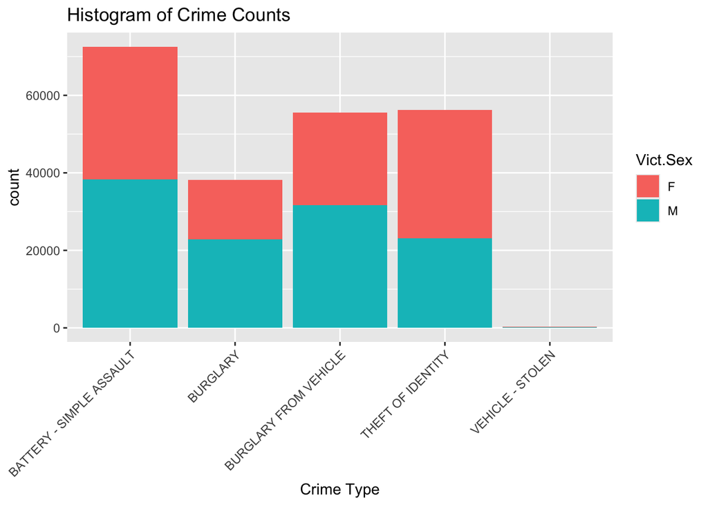

```r
##visualizing crime counts and gender in all 21 areas

ggplot(LAcrime2, aes(x=Crm.Cd.Desc, fill=Vict.Sex))+
  geom_histogram(stat = "count")+
  theme(axis.text.x = element_text(angle = 45, hjust = 1))+
  labs(title = "Histogram of Crime Counts", x="Crime Type")
```

How do the counts of male and female victims compare?

```
##
##      F      M
## 106818 116095
```

There are 116,095 male victims and 106,818 female victims in the data set.

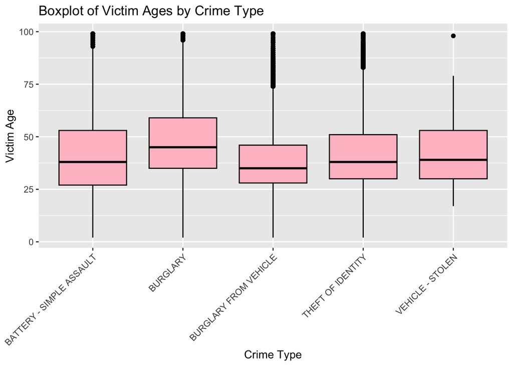

From the above box plot we can see that the median age seems to be the highest for burglary and the lowest for burglary from vehicle. There do seem to be outliers for all of the crimes. We can also observe that the range for each crime is quite similar, except for the range of vehicle stolen, as it is a bit smaller than the others.

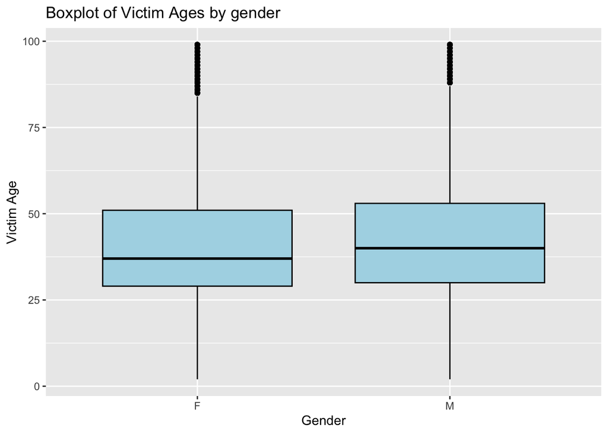

From the above box we can see that the Median age for male victims seems to be slightly greater than the median age for female victims. The range for male and female victims seem to be about the same. Both male victim ages and female victim ages have several outliers towards the top.

Now we will calcultate the crime count for each crime in each area.

```
## # A tibble: 6 × 3
##    AREA Crm.Cd.Desc              Crime_Count
##   <int> <chr>                          <int>
## 1     1 BATTERY - SIMPLE ASSAULT        6620
## 2     1 BURGLARY                        1316
## 3     1 BURGLARY FROM VEHICLE           8416
## 4     1 THEFT OF IDENTITY               1756
## 5     1 VEHICLE - STOLEN                  28
## 6     2 BATTERY - SIMPLE ASSAULT        4063
```

Now we will calculate the proportion of each crime within each area.

```
## # A tibble: 6 × 4
## # Groups:   AREA [2]
##    AREA Crm.Cd.Desc              Crime_Count Proportion_crime
##   <int> <chr>                          <int> <chr>
## 1     1 BATTERY - SIMPLE ASSAULT        6620 0.3650
## 2     1 BURGLARY                        1316 0.0726
## 3     1 BURGLARY FROM VEHICLE           8416 0.4640
## 4     1 THEFT OF IDENTITY               1756 0.0968
## 5     1 VEHICLE - STOLEN                  28 0.0015
## 6     2 BATTERY - SIMPLE ASSAULT        4063 0.4026
```

Now we will calculate the victim demographics that we will be using for clustering. Because there were many outliers in the victim age box plot and we don’t want that to affect our clustering algorithm, we will be using the median age for each. We are using the median because it is less influenced by outliers. On top of median victim age we will also calculate the proportion of male and female victims for each crime in each area.

```
## # A tibble: 6 × 5
## # Groups:   AREA [2]
##    AREA Crm.Cd.Desc              Median_victim_age Proportion_male_victims
##   <int> <chr>                                <dbl>                   <dbl>
## 1     1 BATTERY - SIMPLE ASSAULT              39                     0.581
## 2     1 BURGLARY                              38                     0.661
## 3     1 BURGLARY FROM VEHICLE                 32                     0.602
## 4     1 THEFT OF IDENTITY                     38                     0.585
## 5     1 VEHICLE - STOLEN                      38.5                   0.714
## 6     2 BATTERY - SIMPLE ASSAULT              39                     0.548
## # ℹ 1 more variable: Proportion_female_victims <dbl>
```

Now that we have all of the variables we will be using to preform the clustering, we have to combine them all into a data frame, namely: LAcrime2_final.

To do this we are using a function called left_join().

```
## # A tibble: 105 × 8
##     AREA Crm.Cd.Desc              Crime_Count.x Crime_Count.y Proportion_crime
##    <int> <chr>                            <int>         <int> <chr>
##  1     1 BATTERY - SIMPLE ASSAULT          6620          6620 0.3650
##  2     1 BURGLARY                          1316          1316 0.0726
##  3     1 BURGLARY FROM VEHICLE             8416          8416 0.4640
##  4     1 THEFT OF IDENTITY                 1756          1756 0.0968
##  5     1 VEHICLE - STOLEN                    28            28 0.0015
##  6     2 BATTERY - SIMPLE ASSAULT          4063          4063 0.4026
##  7     2 BURGLARY                          1134          1134 0.1124
##  8     2 BURGLARY FROM VEHICLE             2436          2436 0.2414
##  9     2 THEFT OF IDENTITY                 2455          2455 0.2432
## 10     2 VEHICLE - STOLEN                     5             5 0.0005
## # ℹ 95 more rows
## # ℹ 3 more variables: Median_victim_age <dbl>, Proportion_male_victims <dbl>,
## #   Proportion_female_victims <dbl>
```

```
## # A tibble: 6 × 7
##    AREA Crm.Cd.Desc             Crime_Count.x Proportion_crime Median_victim_age
##   <int> <chr>                           <int> <chr>                        <dbl>
## 1     1 BATTERY - SIMPLE ASSAU…          6620 0.3650                        39
## 2     1 BURGLARY                         1316 0.0726                        38
## 3     1 BURGLARY FROM VEHICLE            8416 0.4640                        32
## 4     1 THEFT OF IDENTITY                1756 0.0968                        38
## 5     1 VEHICLE - STOLEN                   28 0.0015                        38.5
## 6     2 BATTERY - SIMPLE ASSAU…          4063 0.4026                        39
## # ℹ 2 more variables: Proportion_male_victims <dbl>,
## #   Proportion_female_victims <dbl>
```

Now that we have all of the data we are using in LAcrime2_final, we will transform this data from long to wide. Doing this will give us a data frame with 21 rows, each representing an area. We will call this data frame LAcrime2_wide.

```
## # A tibble: 6 × 26
##    AREA Crime_Count_x_BATTERY - …¹ Crime_Count_x_BURGLARY Crime_Count_x_BURGLA…²
##   <int>                      <int>                  <int>                  <int>
## 1     1                       6620                   1316                   8416
## 2     2                       4063                   1134                   2436
## 3     3                       4389                   1344                   1862
## 4     4                       3023                    687                   1165
## 5     5                       3032                   1226                   1418
## 6     6                       4373                   1622                   3888
## # ℹ abbreviated names: ¹`Crime_Count_x_BATTERY - SIMPLE ASSAULT`,
## #   ²`Crime_Count_x_BURGLARY FROM VEHICLE`
## # ℹ 22 more variables: `Crime_Count_x_THEFT OF IDENTITY` <int>,
## #   `Crime_Count_x_VEHICLE - STOLEN` <int>,
## #   `Proportion_crime_BATTERY - SIMPLE ASSAULT` <chr>,
## #   Proportion_crime_BURGLARY <chr>,
## #   `Proportion_crime_BURGLARY FROM VEHICLE` <chr>, …
```

We will take all of the numeric values from LAcrime2_wide so that we can scale the data in order to use it for clustering.

CLUSTERING : :

Compute the (dis)similarity using the euclidean method. :

Convert it into a matrix:

```
##          Area 1   Area 2   Area 3   Area 4   Area 5   Area 6
## Area 1 0.000000 8.063981 9.545065 8.686767 9.314526 5.648608
## Area 2 8.063981 0.000000 4.981552 6.687282 6.579175 5.115849
## Area 3 9.545065 4.981552 0.000000 5.689040 5.320723 6.554829
## Area 4 8.686767 6.687282 5.689040 0.000000 3.343655 6.518257
## Area 5 9.314526 6.579175 5.320723 3.343655 0.000000 7.434703
## Area 6 5.648608 5.115849 6.554829 6.518257 7.434703 0.000000
```

Create hierarchical tree using Ward.D2 method:

create dengrogram using fviz_dend() function from the factoextra package.

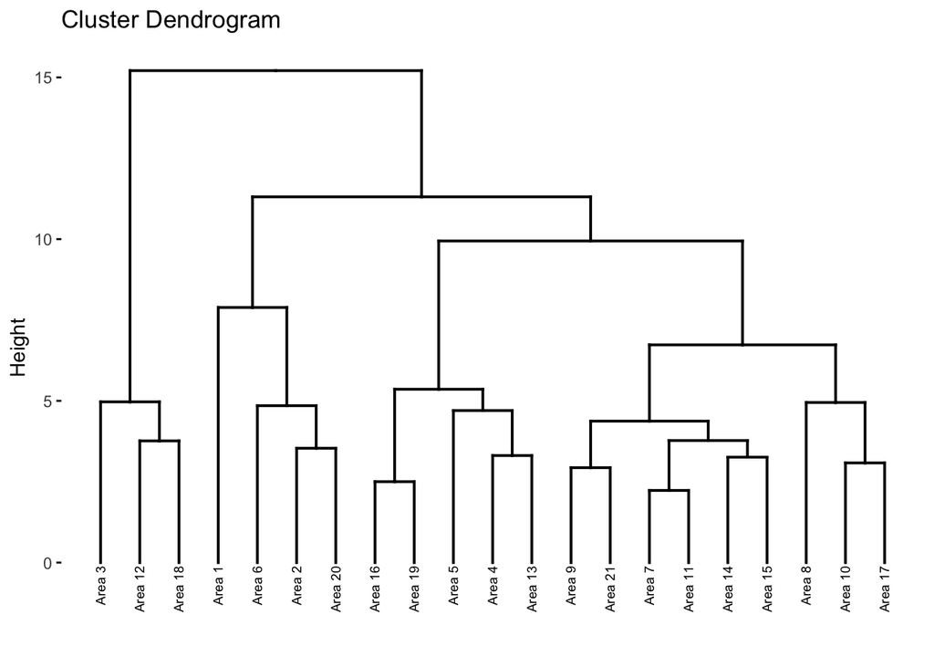

By just looking at the dendrogram we can see that the ideal number of clusters is 4. This is because as we get higher up the tree, the similarity between objects decreases.

Next we will compute the cophentic distance and use that to find the correlation between the cophentic distance and the original distance:

```
## [1] 0.7312219
```

Now we will see if using the average method will give us a better correlation

```
## [1] 0.8054712
```

using the average linkage method creates a tree that represents the original distance better. (correlation = 0.805), but when visualizing the dendrogram using the “average” linkage method, there were two clusters that only contained one area, so we will proceed with the method of Ward.D2

Note: Ward.D2 linkage method is preferred over average linkage method

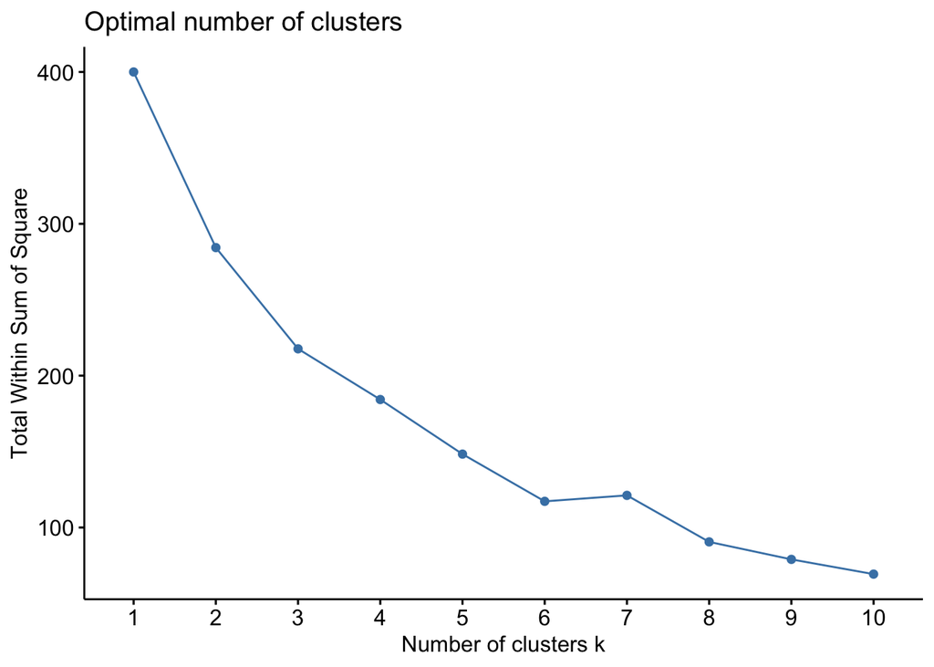

```r
## elbow method to see how many clusters we should take

fviz_nbclust(scaled_data, kmeans, method = "wss") ## method = wss (within cluster sum of squares(variability))
```

Visualizing the dendrogram cut into 4 groups:

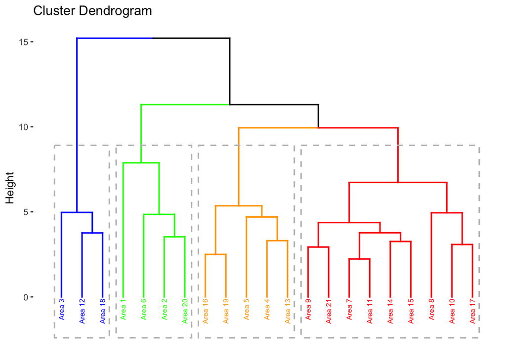

Looking at the dendrogram above we can see the “areas” that will be grouped together. Each cluster is represented by a different color. There is also a box around each cluster for extra clarity.

Visualizing the clusters on a scatter plot:

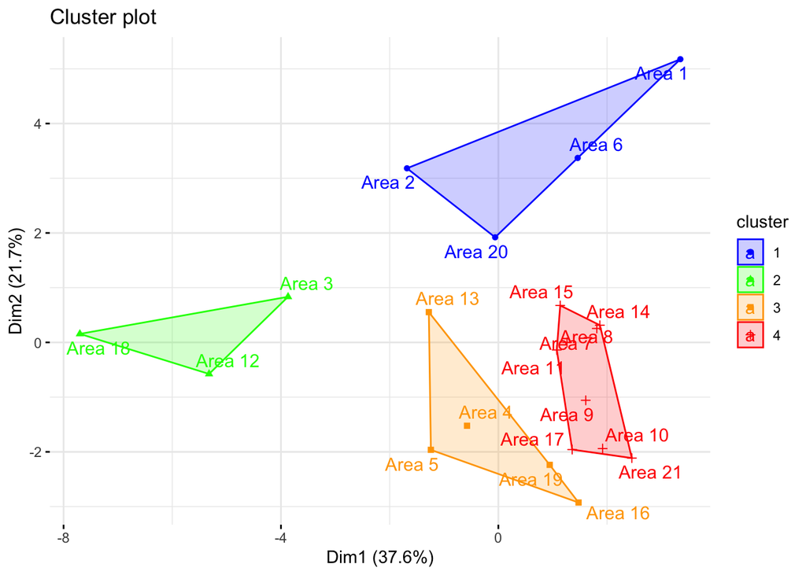

From the above scatter plot, we can see which areas are forming each cluster. It is also good to note that their is no overlap when looking at the clusters. This is what we want, if there were to be overlap there would be similarity between cluster which is not ideal.

How can we compare the areas within each cluster?

Cluster 1 contains:

Area 1, Area 2, Area 6, and Area 20. These areas are “Central”, “Rampart”, “Hollywood” , and “Olympic” respectively.

- Area 1 borders area 2.
- Area 2 borders area 6 and 20
- Area 20 and Area 6 border each other.

Cluster 2 contains:

Area 3, Area 12, and Area 18 These areas are “South West”, “77th”, and “South East” respectively.

- Areas 3 and 12 border each other
- Areas 12 and 18 border each other
- They are all located in south LA. South LA has been known to face challenges with crime,poverty, and socioeconomic disparities.

Cluster 3 contains:

Area 4, Area 5, Area 13, Area 16, Area 19. These areas are “Hollenbeck”, “Harbor”, “Newton”, “Foothill”, “Mission” respectively.

- Area 19 and 16 are bordering regions and are located in the northern part of San Fernando Valley.
- Area 4 and 13 are bordering regions
- Area 5 does not border any of the other regions in cluster 3.

Cluster 4 contains:

Area 7 , Area 8 , Area 9 , Area 10, Area 11,Area 14, Area 15, Area 17, and Area 21. These areas represent, “Wilshire”,“West LA”, “Van Nuys”, “West Valley”, “North East” “Pacific”, “North Hollywood”, “Devon shire”, and “Topanga”.

- Area 7 borders with some of Area 8
- Area 8 borders some of Area 14
- Area 8 borders Area 9 and Area 10
- Area 8 borders some of Area 15
- Area 9 borders Area 10 and Area 15
- Area 10, Area 17, and Area 21 all border each other.
- Some of Area 14 borders Area 8.

Examining the clusters:

Cluster summary 1 - mean crime counts for each cluster:

```
## # A tibble: 4 × 6
##   cluster Mean_Crime_Count_BATTERY Mean_Crime_Count_BUR…¹ Mean_Crime_Count_BUR…²
##     <int>                    <dbl>                  <dbl>                  <dbl>
## 1       1                    4833.                  1466                   4427
## 2       2                    4245.                  1248.                  1616.
## 3       3                    3000.                  1124.                  1604.
## 4       4                    2834.                  2555.                  2774.
## # ℹ abbreviated names: ¹Mean_Crime_Count_BURGLARY,
## #   ²Mean_Crime_Count_BURGLARY_FROM_VEHICLE
## # ℹ 2 more variables: Mean_Crime_Count_THEFT_OF_IDENTITY <dbl>,
## #   Mean_Crime_Count_VEHICLE_STOLEN <dbl>
```

- Looking at the mean crime counts for each crime within each cluster we can see some interesting things.
- We can see that the most prevalent crime in all clusters is battery. The counts for other crimes in these clusters are not too far behind, with the exception of stolen vehicle. In each cluster the count for stolen vehicle is quite low.
- Overall, we can say that the distribution of crime counts is pretty consistent for all clusters.

cluster summary 2 - mean victim age for each crime (grouped by cluster):

```
## # A tibble: 4 × 6
##   cluster mean_vict_age_BATTERY mean_vict_age_BURGLARY mean_vict_age_BURGULARY…¹
##     <int>                 <dbl>                  <dbl>                     <dbl>
## 1       1                  38                     41.4                      33
## 2       2                  37.7                   42.7                      37
## 3       3                  38.4                   45.8                      36.6
## 4       4                  39                     46.4                      36.9
## # ℹ abbreviated name: ¹mean_vict_age_BURGULARY_FROM_VEHICLE
## # ℹ 2 more variables: mean_vict_age_THEFT_OF_IDENTITY <dbl>,
## #   mean_vict_age_VEHICLE_STOLEN <dbl>
```

From the summary of mean victim ages across the clusters we can note:

- The mean victim age for battery seems to range from about 38-39.
- The mean victim age for burglary ranges from 41-46.
- The mean victim age for burglary from vehicle ranges from 33-37
- The mean victim age for theft of identity ranges from 35-41.
- The mean victim age for vehicle stolen ranges from 33-43.
- Overall, The ages all seem to range from mid 30’s to early 40’s. Why is this? Could it have to do with the age demographics or age distribution in LA as a whole? Is it because they are more likely to be involved in activities or situations that increase their risk of becoming a victim such as enjoying night life, social events, owning vehicles,ect.

cluster summary 3 - calculating all of the mean victim proportions of male/female for battery-simple assault by cluster:

```
## # A tibble: 4 × 3
##   cluster mean_prop_male_vict_BATTERY mean_prop_female_vict_BATTERY
##     <int>                       <dbl>                         <dbl>
## 1       1                       0.571                         0.429
## 2       2                       0.436                         0.564
## 3       3                       0.503                         0.497
## 4       4                       0.552                         0.448
```

- The proportion for male and female victims across all clusters seem to be about the same, with proportion of males being slightly greater, other than in Cluster 2 .
- Cluster 2 consists of “Area 3” “Area 12” “Area 18”. These areas are “South West”, “77th”, and “South East” respectively. These three areas are boarding neighborhoods.These neighborhoods are also all in South LA which has had problems with crime as well as differences in socioeconomic classes. Could the population of women in these areas be greater than the population of men? Further investigation into the demographics of these areas could reveal why the proportion on female victims is higher in this cluster / in the neighborhoods making up this cluster.
- According to statista.com the number of male victims of violent crimes (from 2005-2022) are typically slightly higher. This data agrees with that, suggesting a consistency in gender dynamics when looking a violent crimes (battery)
- Seeing that the proportion of male victims is higher than the proportion of female victims is an interesting observation because it is breaking stereotypes about victims, it is thought that typically males are perpetrators rather than victims, but this gives us a different insight.

https://www.statista.com/statistics/423245/us-violent-crime-victims-by-gender/

cluster summary 4 - calculating the mean victim proportions of male/female for burglary by cluster:

```
## # A tibble: 4 × 3
##   cluster mean_prop_male_vict_BURGLARY mean_prop_women_vict_BURGLARY
##     <int>                        <dbl>                         <dbl>
## 1       1                        0.577                         0.423
## 2       2                        0.467                         0.533
## 3       3                        0.601                         0.399
## 4       4                        0.621                         0.379
```

The summary of mean male/female victim proportions of burglary reveals that men have a higher proportion than females in clusters 1,3, and 4. The proportion of women is slightly higher in Cluster 2 . In Cluster 3 and Cluster 4 we can see that there is quite a large difference in the proportion of male victims compared to women victims, there is nearly a 20% and 25% difference of proportions in Cluster 3 and Cluster 4 respectively.

Cluster 3 contains, “Area 4” , “Area 5”, “Area 13”,“Area 16”, and “Area 19”. These areas represent, “Hollen Beck”, “Harbor”,“Newton”,“Foot Hill”,and “Mission” respectively.

Note:

-Areas 4 and 13 are bordering neighborhoods.

-Areas 16 and 19 are also bordering neighborhoods

Cluster 4 contains, “Area 7” , “Area 8” , “Area 9” , “Area 10”, “Area 11”,“Area 14”, “Area 15”, “Area 17”, and “Area 21”. These areas represent, “Wilshire”,“West LA”, “Van Nuys”, “West Valley”, “North East” “Pacific”, “North Hollywood”, “Devon shire”, and “Topanga”.

- It is interesting to note that areas 8, 9,10,15,17, and 21 are all bordering neighborhoods.
- Further investigation of these areas could give us valuable insights. Somethings I would be interested to further investigate include, socioeconomic classes, victim vulnerability (lifestyle, occupation, awareness). It would be interesting to see the time of day these crimes occurred, if they are mostly at night is there a heavy presence of night life in the areas?

cluster summary 5 - calculating all of the mean victim proportions of male/female for burglary from vehicle by cluster:

```
## # A tibble: 4 × 3
##   cluster mean_prop_male_vict_BURGLARY_FROM_VEHICLE mean_prop_female_vict_BURG…¹
##     <int>                                     <dbl>                        <dbl>
## 1       1                                     0.575                        0.425
## 2       2                                     0.495                        0.505
## 3       3                                     0.601                        0.399
## 4       4                                     0.565                        0.435
## # ℹ abbreviated name: ¹mean_prop_female_vict_BURGLARY_FROM_VEHICLE
```

- The summary for mean proportion of male/female victims of burglary from vehicle reveals that for all clusters other than Cluster 2 , the proportion of male victims is greater than the proportion of female victims.
- We can see that Cluster 3 has nearly a 20% difference in male victims vs female victims.
- Once again it would be interesting to further look into these crimes. Time of crime, male population vs female population, socioeconomic classes, education, etc could give us valuable information.

cluster summary 6 - calculating all of the mean victim proportions of male/female for theft of identity from vehicle by cluster:

```
## # A tibble: 4 × 3
##   cluster mean_prop_male_vict_THEFT_OF_IDENTITY mean_prop_female_vict_THEFT_OF…¹
##     <int>                                 <dbl>                            <dbl>
## 1       1                                 0.494                            0.506
## 2       2                                 0.285                            0.715
## 3       3                                 0.350                            0.650
## 4       4                                 0.467                            0.533
## # ℹ abbreviated name: ¹mean_prop_female_vict_THEFT_OF_IDENTITY
```

The summary for mean proportion of male/female victims for theft of identity reveals different trends for each cluster.

- Cluster 1 has slightly more female victims
- Cluster 2 has notably more female victims
- Cluster 3 has notably more female victims
- Cluster 4 has slightly more female victims

Let’s examine cluster 2 & 3:

- Cluster 2 consists of “Area 3” “Area 12” “Area 18”. These areas are “South West”, “77th”, and “South East” respectively. All of these areas are in South LA, which is known for having challenges with crimes and socioeconomic disparities.
- Cluster 3 consists of “Area 4” , “Area 5”, “Area 13”,“Area 16”, and “Area 19”. These areas represent, “Hollen Beck”, “Harbor”,“Newton”,“Foot Hill”,and “Mission” respectively.
- Unfortunately we don’t know the demographics of these areas, but if we did we would be interested to see if there are more female residents than male residents. We could look into shopping aspects, are there many shops catered towards women that could be stealing their information/identity? We could even look into the demographics of these people. We could examine their education and socioeconomic class to see if they are more susceptible to identity theft.

cluster summary 7 - calculating all of the mean victim proportions of male/female for vehicle stolen by cluster:

```
## # A tibble: 4 × 3
##   cluster mean_prop_male__vict_VEHICLE_STOLEN mean_prop_female_vict_VEHICLE_ST…¹
##     <int>                               <dbl>                              <dbl>
## 1       1                               0.579                              0.421
## 2       2                               0.554                              0.446
## 3       3                               0.796                              0.204
## 4       4                               0.727                              0.273
## # ℹ abbreviated name: ¹mean_prop_female_vict_VEHICLE_STOLEN
```

- The summary for mean proportion of male/female victims for vehicle stolen shows that there are more male victims than female victims for each cluster. It is interesting to note that clusters 3 and 4 have a big difference in proportions.
- To further investigate this we could look into socioeconomic factors such as income and employment.Lower income areas could be more susceptible to this type of crime. We could look into population of these areas, are there more men? Maybe more men own vehicles making them more vulnerable to this crime.

Conclusions and recommendations : :

Research Question : :

How can we group the 21 geographical areas of LA when considering the top 5 crimes based on victim demographics such as age and gender, and crime count? Based off of these groupings, how do the victim demographics and crime count compare?

Future Recommendations:

For future analysis I would like to examine several factors about the victims.Specifically I would like to explore socioeconomic status. By socioeconomic status I mean, income, education, and occupation. Exploring variables like these and including it in our clustering algorithm would give us an deeper insights on victimization rates and would give us the ability to identify vulnerable groups of people. Gaining an understanding on how socioeconomic status relates to victimization would not only be interesting to see, it would enable change for communities by informing vulnerable groups.

Another variable that would be interesting to look into is time. Incorporating time into the analysis would give us an idea of what crimes happen when and in what areas are crimes more likely to occur at a given time. Knowing this information would be great for police to know so they can patrol certain areas more heavily at certain times of day. Knowing the time distribution of crimes would also be beneficial to residents of high crime regions. Knowing that a certain crime is more likely to occur at a specific time in an area will bring awareness to potential victims and hopefully keep them safe.

On the flip side, I would be really interested in looking into perpetrator demographics. Some of these demographics include age, sex, education, income, occupation,etc. Looking into the perpetrator side of things would give great insights into the cause rather than the effect of crimes. Knowing this information could help prevent crimes from taking place.

For future analysis, we could compare crime dendrograms of different cities in California to see how they compare. By comparing these dendrograms we can identify similarities in crime trends. These similarities can reveal commonalities in crimes patterns and dynamics across cities in California. These comparisons can reveal geographical trends, geographical variations, and factors that influence crimes. Knowing how a whole state of cities compare can lead to solving crime issues and making the state safer as a whole.

This is just a start, there are many other statistical analysis techniques that could be applied to my data to explore crime trends and patterns. All of these techniques would provide valuable insights of crime dynamics. By using these techniques and understanding the outcomes we can develop strategies for crime prevention as well as victim protection.

Bibliography:

Ganguly, A. (2023, September 12). How to do left join in R?: 2 methods (with examples). FavTutor. https://favtutor.com/blogs/left-join-r

Kassambara, A. (2017). Practical guide to cluster analysis in R: Unsupervised machine learning. STHDA.

Korhonen, V. (2023, October 26). U.S. violent crime victims, by gender 2022. Statista. https://www.statista.com/statistics/423245/us-violent-crime-victims-by-gender/

Wickham, H. (n.d.). Pivot data from long to wide - pivot_wider. - pivot_wider • tidyr. https://tidyr.tidyverse.org/reference/pivot_wider.html